# Explore_mtcars app

22/04/2021

## Why mtcars?

We have seen the mtcars dataset several times in various courses of the Data Science Specialization.

Although it is small, only 32 rows, it has a complex structure with 11 variables more or less correlated with one another.

Including or excluding certain variables from linear regression models can cause surprising changes in the coefficients of other variables.

Despite repeated exposure I still didn’t intuitively understand how the variables of mtcar related to each other.

I designed the Explore_mtcars app to help me explore these relationships visually.

## App structure

- The backbone of the app is a linear regression of miles per gallon on weight, displayed in a plot.
  - Weight is the single variable that explains the largest part of the variation in miles per gallon by itself.
- The user can choose one of four variables to add to the regression model.
  - The choices are all discrete variables that can be converted to factors with 2-4 levels.
  - The plot updates to show the new regression. The data points and regression line segments are color-coded according to the factor levels.
  - The fraction of variation explained by the regression and the probability of the null hypothesis that the added variable has no effect are reported below the plot.
- The user can choose to show or hide car model name labels for each data point.

## Sample output with Cylinders selected

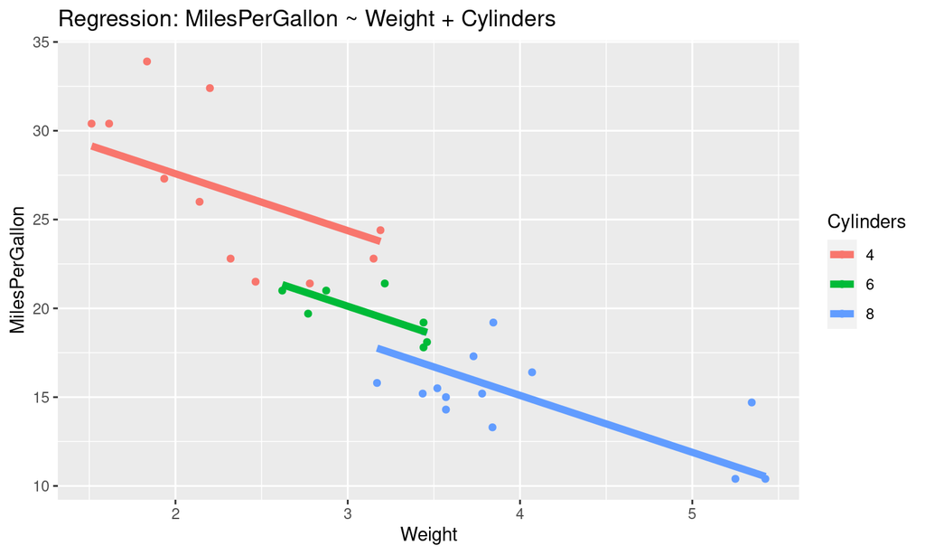

R-squared: 0.8374  
Probability that Cylinders has no effect: 0.001

## Sample output with labels displayed

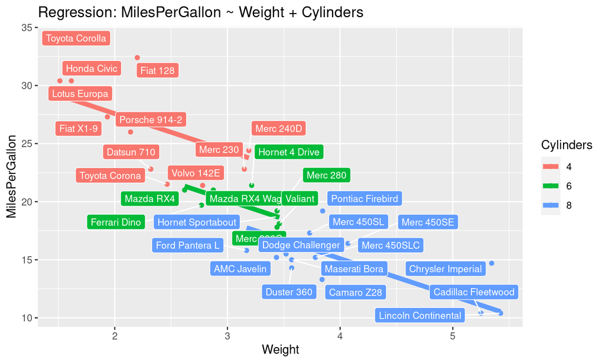

R-squared: 0.8374  
Probability that Cylinders has no effect: 0.001